# Week 1: Data Preprocessing

Big Data and Machine Learning for Applied Economics | [MECA-4107](https://bloqueneon.uniandes.edu.co/d2l/home/130328)

Eduard-Martínez

Universidad de los Andes

## **0. Initial configuration**

Require the libraries of this class:

```r
## install pacman
if(!require(pacman)) install.packages("pacman") ; require(pacman)
## require/install packages on this session
require(pacman)
p_load(rio, # import/export data
       tidyverse, # tidy-data
       skimr, # summary data
       caret) # Classification And REgression Training

## set seed
set.seed(0000)
```

## **1. load data**

First we are going to import some part of the GEIH data that will be used in the **problem-set 1**. The data dictionary is available [here](https://ignaciomsarmiento.github.io/GEIH2018_sample/dictionary.html)

```r
## load data
db <- import("https://gitlab.com/Lectures-R/bd-meca-2022-summer/lecture-01/-/raw/main/data/GEIH_sample1.Rds")
```

#### **1.1. dataframe vs tibble**

**Wha is a tibble?:** Tibbles are a modern take on data frames. They keep the features that have stood the test of time, and drop the features that used to be convenient but are now frustrating (i.e. converting character vectors to factors).

Then, **Why should I use them?:** There are three key differences between tibbles and data frames: printing, subsetting, and recycling rules. Run `vignette("tibble")` on the console to read more about it.

```r
db <- as_tibble(db) ## from dataframe to tibble
```

#### **1.2. Inspect data**

You can print in console both first or last database observations:

```r
## print data
head(db)
```

```
## # A tibble: 6 × 178
##   Var.1 directorio secuencia_p orden clase dominio   mes estrato1   sex   age
##   <int>      <int>       <int> <int> <int> <chr>   <int>    <int> <int> <int>
## 1     1    4514331           1     2     1 BOGOTA      1        2     0    29
## 2     2    4514331           1     1     1 BOGOTA      1        2     1    36
## 3     3    4514332           1     4     1 BOGOTA      1        2     1     4
## 4     4    4514332           1     3     1 BOGOTA      1        2     1     7
## 5     5    4514332           1     1     1 BOGOTA      1        2     0    32
## 6     6    4514332           1     2     1 BOGOTA      1        2     1    35
## # … with 168 more variables: p6050 <int>, p6090 <int>, p6100 <int>,
## #   p6210 <int>, p6210s1 <int>, p6240 <int>, oficio <int>, p6426 <int>,
## #   relab <int>, p6500 <dbl>, p6510 <int>, p6510s1 <dbl>, p6510s2 <int>,
## #   p6545 <int>, p6545s1 <dbl>, p6545s2 <int>, p6580 <int>, p6580s1 <dbl>,
## #   p6580s2 <int>, p6585s1 <int>, p6585s1a1 <dbl>, p6585s1a2 <int>,
## #   p6585s2 <int>, p6585s2a1 <dbl>, p6585s2a2 <int>, p6585s3 <int>,
## #   p6585s3a1 <dbl>, p6585s3a2 <int>, p6585s4 <int>, p6585s4a1 <dbl>, …
```

```r
tail(db)
```

```
## # A tibble: 6 × 178
##   Var.1 directorio secuencia_p orden clase dominio   mes estrato1   sex   age
##   <int>      <int>       <int> <int> <int> <chr>   <int>    <int> <int> <int>
## 1  3212    4540692           1     6     1 BOGOTA      2        2     0    12
## 2  3213    4540693           1     1     1 BOGOTA      2        3     0    50
## 3  3214    4540693           1     2     1 BOGOTA      2        3     0    22
## 4  3215    4540693           1     3     1 BOGOTA      2        3     0    15
## 5  3216    4540694           1     3     1 BOGOTA      2        2     0     7
## 6  3217    4540694           1     1     1 BOGOTA      2        2     1    56
## # … with 168 more variables: p6050 <int>, p6090 <int>, p6100 <int>,
## #   p6210 <int>, p6210s1 <int>, p6240 <int>, oficio <int>, p6426 <int>,
## #   relab <int>, p6500 <dbl>, p6510 <int>, p6510s1 <dbl>, p6510s2 <int>,
## #   p6545 <int>, p6545s1 <dbl>, p6545s2 <int>, p6580 <int>, p6580s1 <dbl>,
## #   p6580s2 <int>, p6585s1 <int>, p6585s1a1 <dbl>, p6585s1a2 <int>,
## #   p6585s2 <int>, p6585s2a1 <dbl>, p6585s2a2 <int>, p6585s3 <int>,
## #   p6585s3a1 <dbl>, p6585s3a2 <int>, p6585s4 <int>, p6585s4a1 <dbl>, …
```

You can get a complete description of the database using the `skim()` function of the `skimr` library. However, you can to produce result summaries of the a variable using `summary()` function. Let me show you a example:

```r
## summary db
skim(db) %>% head()
```

Data summary

| Name | db |
| --- | --- |
| Number of rows | 3217 |
| Number of columns | 178 |
| _______________________ |  |
| Column type frequency: |  |
| character | 1 |
| logical | 2 |
| numeric | 3 |
| ________________________ |  |
| Group variables | None |

**Variable type: character**

| skim_variable | n_missing | complete_rate | min | max | empty | n_unique | whitespace |
| --- | --- | --- | --- | --- | --- | --- | --- |
| dominio | 0 | 1 | 6 | 6 | 0 | 1 | 0 |

**Variable type: logical**

| skim_variable | n_missing | complete_rate | mean | count |
| --- | --- | --- | --- | --- |
| p550 | 3217 | 0 | NaN | : |
| y_gananciaNetaAgro_m | 3217 | 0 | NaN | : |

**Variable type: numeric**

| skim_variable | n_missing | complete_rate | mean | sd | p0 | p25 | p50 | p75 | p100 | hist |
| --- | --- | --- | --- | --- | --- | --- | --- | --- | --- | --- |
| Var.1 | 0 | 1 | 1609.00 | 928.81 | 1 | 805 | 1609 | 2413 | 3217 | ▇▇▇▇▇ |
| directorio | 0 | 1 | 4527886.71 | 9151.40 | 4514331 | 4521292 | 4526845 | 4535725 | 4540694 | ▃▅▅▁▇ |
| secuencia_p | 0 | 1 | 1.02 | 0.18 | 1 | 1 | 1 | 1 | 4 | ▇▁▁▁▁ |

```r
## summary var
summary(db$y_salary_m)
```

```
##     Min.  1st Qu.   Median     Mean  3rd Qu.     Max.     NA's
##    40000   737717   860000  1383727  1300000 30000000     2286
```

## **2. visualize data**

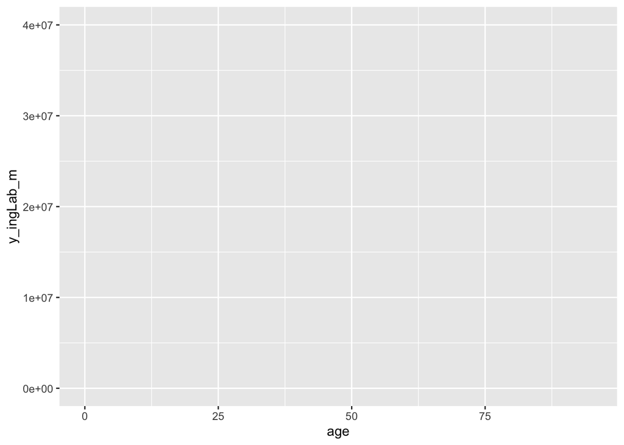

```r
## data + mapping
ggplot(data = db , mapping = aes(x = age , y = y_ingLab_m))
```

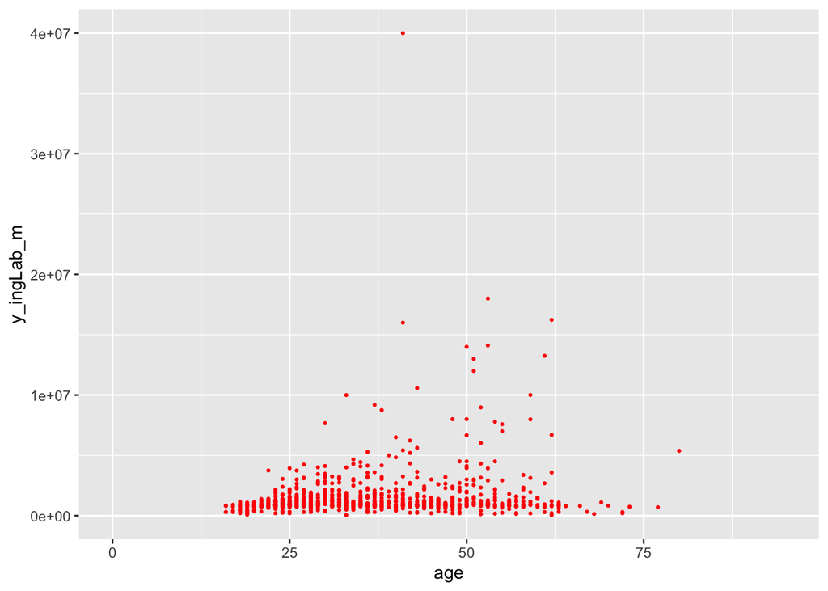

```r
## + geometry
ggplot(data = db , mapping = aes(x = age , y = y_ingLab_m)) +
geom_point(col = "red" , size = 0.5)
```

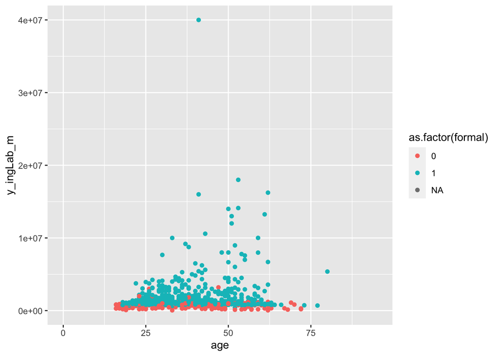

```r
## by group
ggplot(data = db ,
       mapping = aes(x = age , y = y_ingLab_m , group=as.factor(formal) , color=as.factor(formal))) +
       geom_point()
```

You can save the chart in a object:

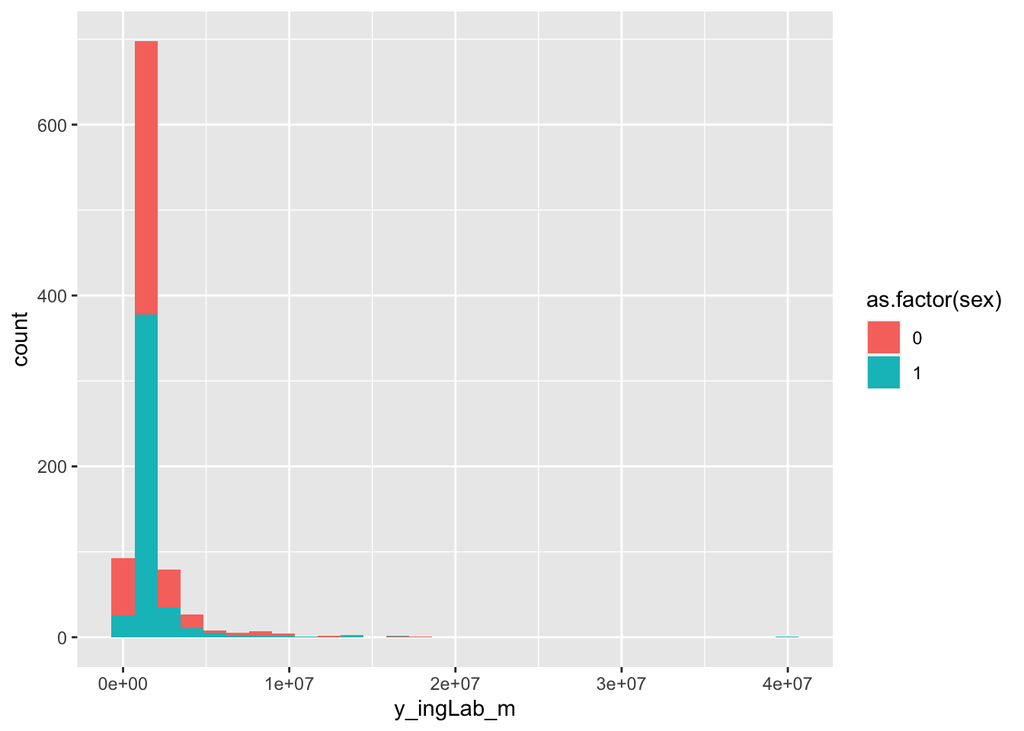

```r
## density: income by sex
p <- ggplot(data=db) +
     geom_histogram(mapping = aes(x=y_ingLab_m , group=as.factor(sex) , fill=as.factor(sex)))
p
```

And you can add attributes to the object that contains the chart:

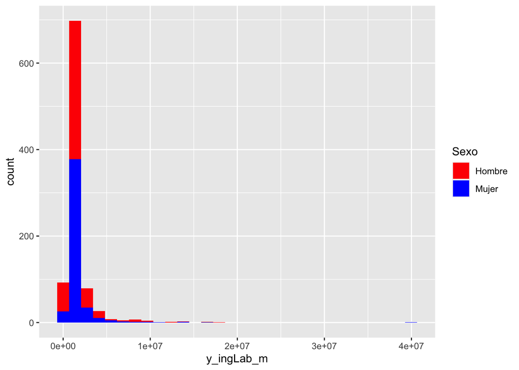

```r
p + scale_fill_manual(values = c("0"="red" , "1"="blue") , label = c("0"="Hombre" , "1"="Mujer") , name = "Sexo")
```

Boxplot chart:

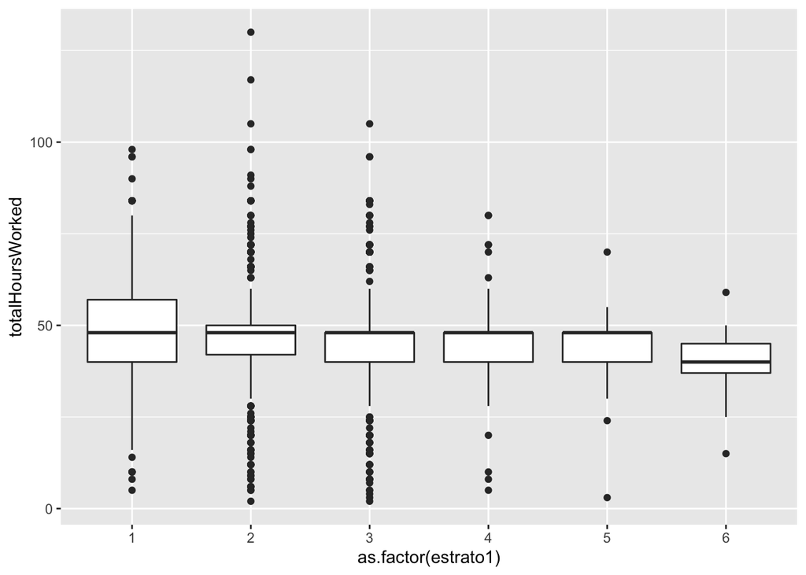

```r
## box_plot: estrato1 vs totalHoursWorked
box_plot <- ggplot(data=db , mapping = aes(as.factor(estrato1) , totalHoursWorked)) +
            geom_boxplot()
box_plot
```

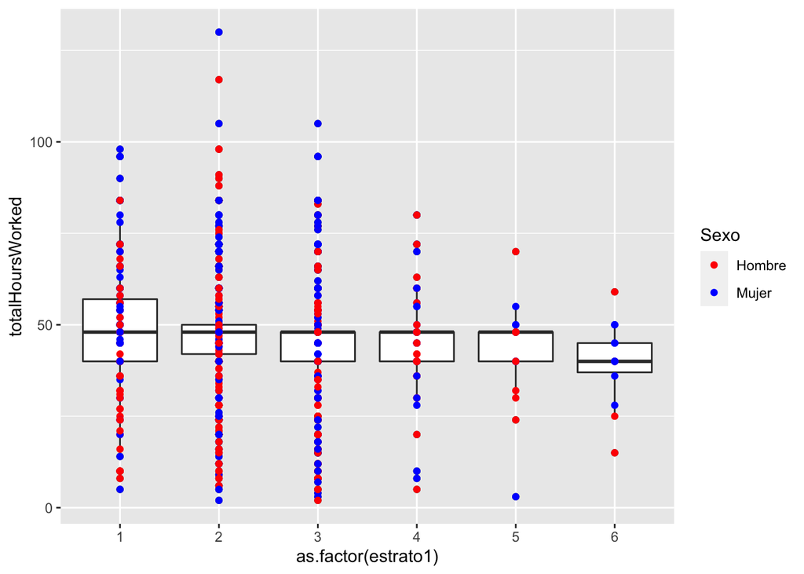

```r
## add another geometry
box_plot <- box_plot +
            geom_point(aes(colour=as.factor(sex))) +
            scale_color_manual(values = c("0"="red" , "1"="blue") , label = c("0"="Hombre" , "1"="Mujer") , name = "Sexo")
box_plot
```

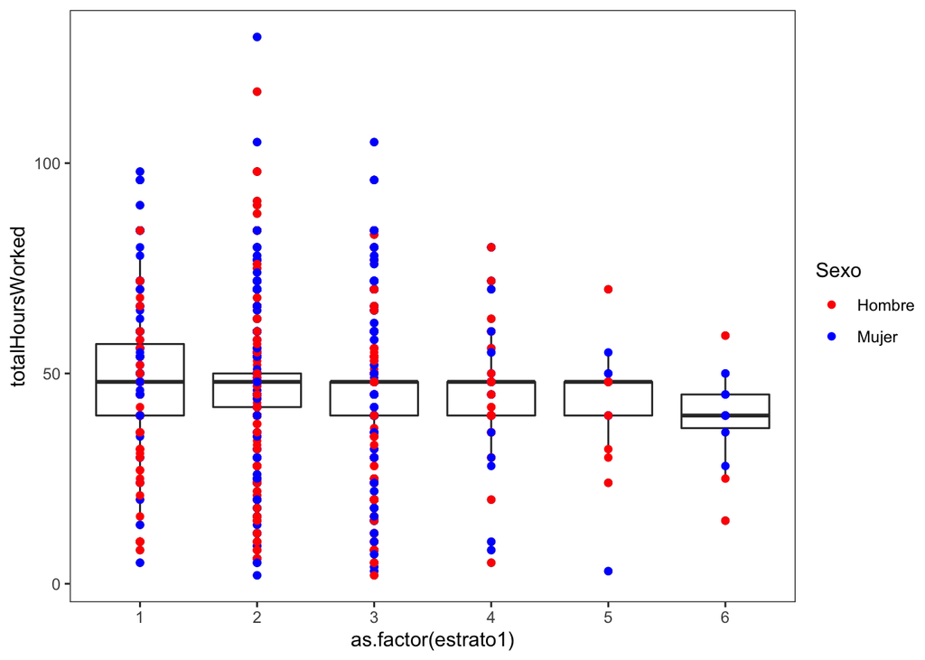

```r
## add theme
box_plot + theme_test()
```

## **3. transformations**

#### **3.1 centering and scaling**

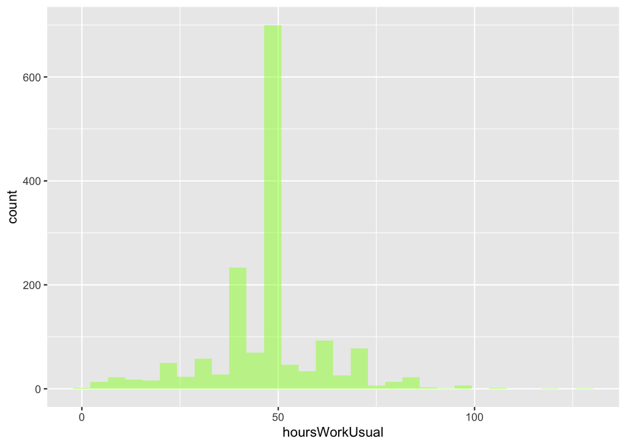

```r
h_hour = ggplot() + geom_histogram(data=db , aes(x=hoursWorkUsual) , fill="#99FF33" , alpha=0.5)
h_hour
```

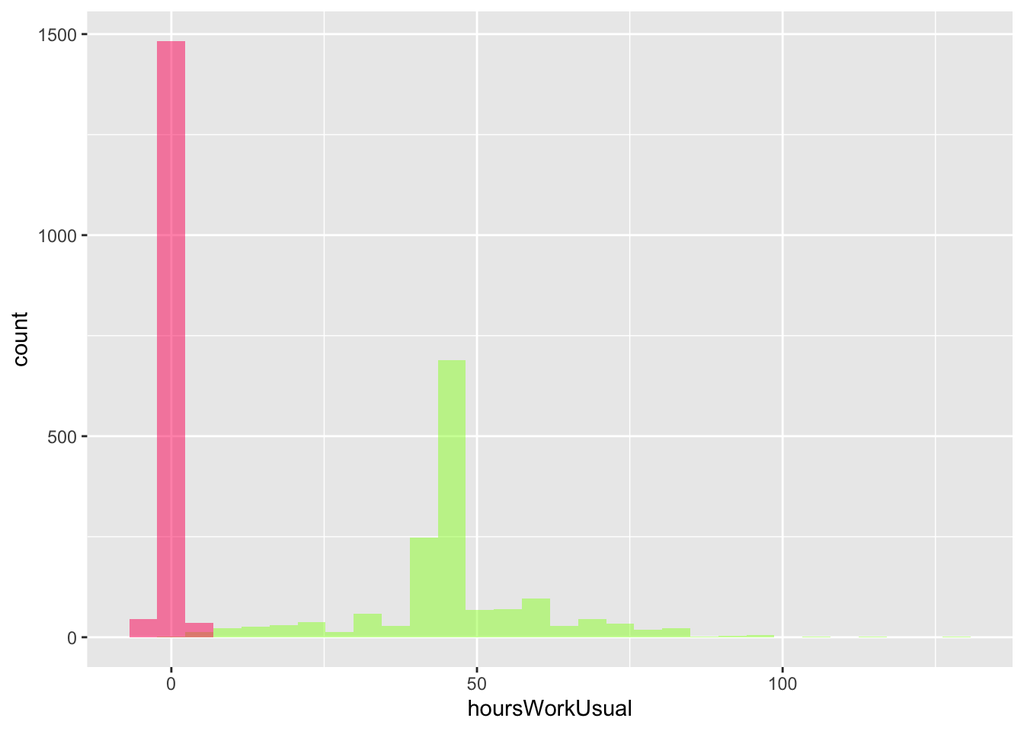

```r
db = db %>% mutate(esc_hoursWorkUsual = scale(hoursWorkUsual))

h_hour + geom_histogram(data=db , aes(x=esc_hoursWorkUsual) , fill="#FF0066" , alpha=0.5)
```

#### **3.2 Skewness: log**

```r
BoxCoxTrans(db$y_ingLab_m)
```

[output not shown]

**Aaaa! We’ll deal with NAs in a while, let’s avoid them for now!**

```r
BoxCoxTrans(db$y_ingLab_m , na.rm=T)
```

```
## Box-Cox Transformation
##
## 931 data points used to estimate Lambda
##
## Input data summary:
##     Min.  1st Qu.   Median     Mean  3rd Qu.     Max.
##    40000   820857   983140  1547069  1498083 40000000
##
## Largest/Smallest: 1000
## Sample Skewness: 8.63
##
## Estimated Lambda: -0.1
## With fudge factor, Lambda = 0 will be used for transformations
```

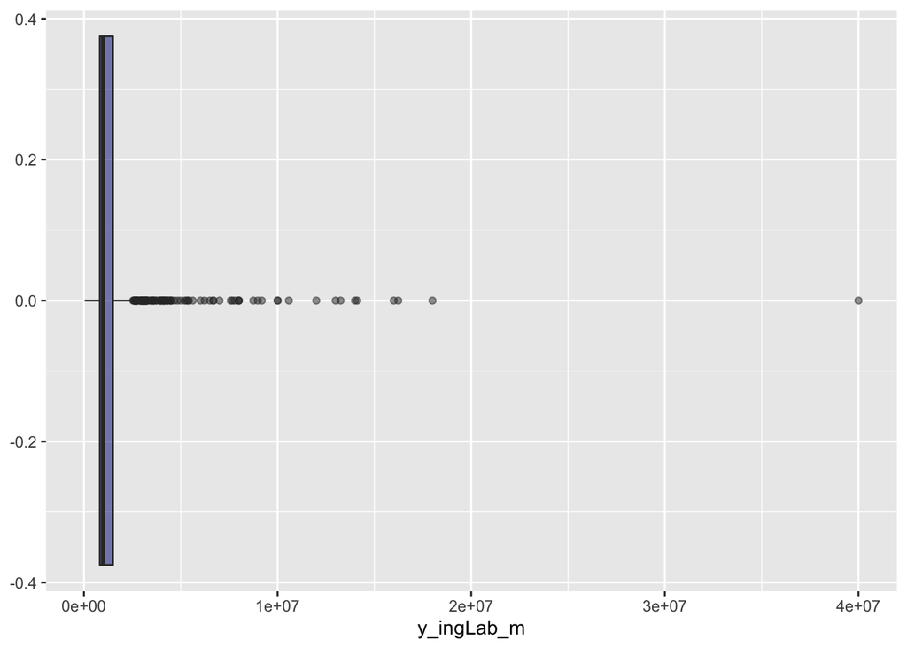

```r
ggplot() + geom_boxplot(data=db ,aes(x=y_ingLab_m) , fill="darkblue" , alpha=0.5)
```

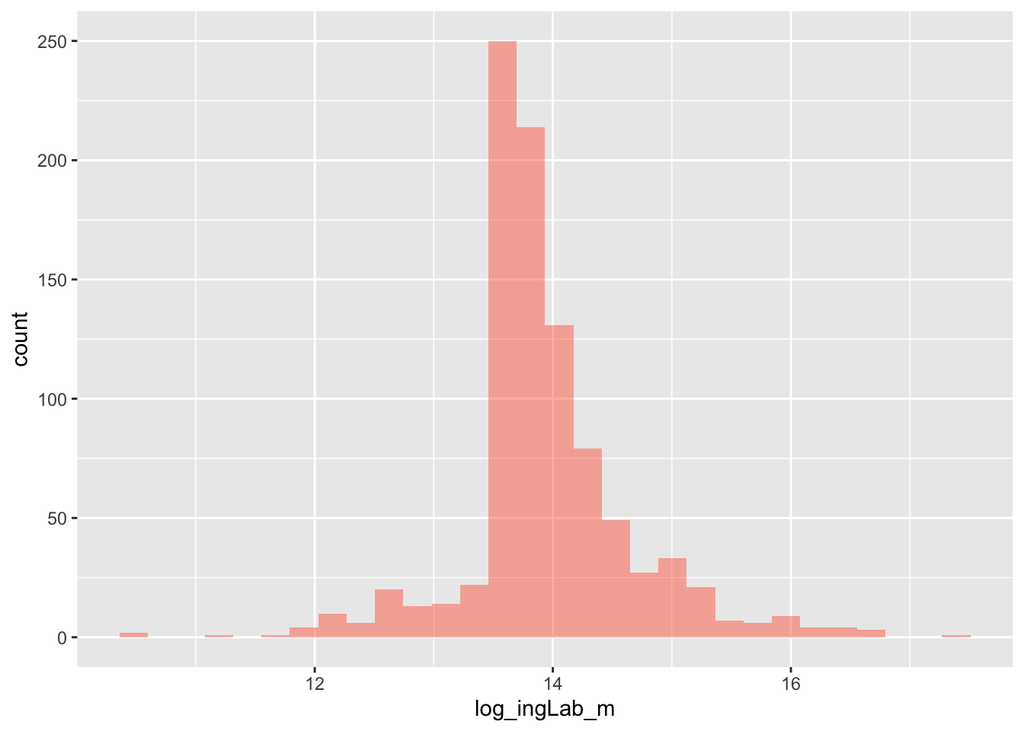

```r
db <- db %>% mutate(log_ingLab_m=log(y_ingLab_m))

ggplot() + geom_histogram(data=db , aes(x=log_ingLab_m) , fill="coral1" , alpha=0.5)
```

#### **3.3 resolve outliers**

```r
quantile(x=db$p6426 , na.rm=T)
```

```
##   0%  25%  50%  75% 100%
##    0    8   30   84  600
```

```r
IQR(x=db$p6426 , na.rm=T)
```

```
## [1] 76
```

```r
iqr <- IQR(x=db$p6426 , na.rm=T)

db_out <- db %>% subset(p6426 <= 2*iqr | is.na(p6426)==T)

cat("¡Elimina las NA!")
```

```
## ¡Elimina las NA!
```

```r
quantile(x=db_out$p6426 , na.rm=T)
```

```
##   0%  25%  50%  75% 100%
##    0    6   24   56  148
```

```r
nrow(db) - nrow(db_out)
```

```
## [1] 208
```

## **4. Create, modify, and delete columns**

#### **4.1 dummy vars**

```r
db = db %>%
     mutate(p6426_out = ifelse(test = p6426 > 4*iqr,
                               yes = 1,
                               no = 0))
table(db$p6426_out)
```

```
##
##    0    1
## 1499   66
```

#### **4.2 multiple categorical var**

```r
q = quantile(db$p6426 , na.rm=T)
q
```

```
##   0%  25%  50%  75% 100%
##    0    8   30   84  600
```

```r
db = db %>%
     mutate(p6426_q = case_when(p6426 < q[2] ~ "Q-1",
                                p6426 >= q[2] & p6426 < q[3] ~ "Q-2",
                                p6426 >= q[3] & p6426 < q[4] ~ "Q-3",
                                p6426 >= q[4] ~ "Q-4"))
table(db$p6426_q)
```

```
##
## Q-1 Q-2 Q-3 Q-4
## 375 404 376 410
```

#### **4.3 keeping only some vars**

```r
## select: delete a variable
head(db)
```

```
## # A tibble: 6 × 182
##   Var.1 directorio secuencia_p orden clase dominio   mes estrato1   sex   age
##   <int>      <int>       <int> <int> <int> <chr>   <int>    <int> <int> <int>
## 1     1    4514331           1     2     1 BOGOTA      1        2     0    29
## 2     2    4514331           1     1     1 BOGOTA      1        2     1    36
## 3     3    4514332           1     4     1 BOGOTA      1        2     1     4
## 4     4    4514332           1     3     1 BOGOTA      1        2     1     7
## 5     5    4514332           1     1     1 BOGOTA      1        2     0    32
## 6     6    4514332           1     2     1 BOGOTA      1        2     1    35
## # … with 172 more variables: p6050 <int>, p6090 <int>, p6100 <int>,
## #   p6210 <int>, p6210s1 <int>, p6240 <int>, oficio <int>, p6426 <int>,
## #   relab <int>, p6500 <dbl>, p6510 <int>, p6510s1 <dbl>, p6510s2 <int>,
## #   p6545 <int>, p6545s1 <dbl>, p6545s2 <int>, p6580 <int>, p6580s1 <dbl>,
## #   p6580s2 <int>, p6585s1 <int>, p6585s1a1 <dbl>, p6585s1a2 <int>,
## #   p6585s2 <int>, p6585s2a1 <dbl>, p6585s2a2 <int>, p6585s3 <int>,
## #   p6585s3a1 <dbl>, p6585s3a2 <int>, p6585s4 <int>, p6585s4a1 <dbl>, …
```

```r
db %>% select(-Var.1,-orden)
```

```
## # A tibble: 3,217 × 180
##    directorio secuencia_p clase dominio   mes estrato1   sex   age p6050 p6090
##         <int>       <int> <int> <chr>   <int>    <int> <int> <int> <int> <int>
##  1    4514331           1     1 BOGOTA      1        2     0    29     2     1
##  2    4514331           1     1 BOGOTA      1        2     1    36     1     1
##  3    4514332           1     1 BOGOTA      1        2     1     4     3    NA
##  4    4514332           1     1 BOGOTA      1        2     1     7     3    NA
##  5    4514332           1     1 BOGOTA      1        2     0    32     1     1
##  6    4514332           1     1 BOGOTA      1        2     1    35     2     1
##  7    4514333           1     1 BOGOTA      1        2     1    18     3     1
##  8    4514333           1     1 BOGOTA      1        2     0    49     2     1
##  9    4514333           1     1 BOGOTA      1        2     1    51     1     1
## 10    4514333           1     1 BOGOTA      1        2     0    23     3     1
## # … with 3,207 more rows, and 170 more variables: p6100 <int>, p6210 <int>,
## #   p6210s1 <int>, p6240 <int>, oficio <int>, p6426 <int>, relab <int>,
## #   p6500 <dbl>, p6510 <int>, p6510s1 <dbl>, p6510s2 <int>, p6545 <int>,
## #   p6545s1 <dbl>, p6545s2 <int>, p6580 <int>, p6580s1 <dbl>, p6580s2 <int>,
## #   p6585s1 <int>, p6585s1a1 <dbl>, p6585s1a2 <int>, p6585s2 <int>,
## #   p6585s2a1 <dbl>, p6585s2a2 <int>, p6585s3 <int>, p6585s3a1 <dbl>,
## #   p6585s3a2 <int>, p6585s4 <int>, p6585s4a1 <dbl>, p6585s4a2 <int>, …
```

```r
## select variable: by patter name
db %>% select(starts_with("p6"))
```

```
## # A tibble: 3,217 × 53
##    p6050 p6090 p6100 p6210 p6210s1 p6240 p6426   p6500 p6510 p6510s1 p6510s2
##    <int> <int> <int> <int>   <int> <int> <int>   <dbl> <int>   <dbl>   <int>
##  1     2     1     2     5      11     6    NA      NA    NA      NA      NA
##  2     1     1     2     5      11     1   166 1300000     2       0      NA
##  3     3    NA    NA     2      NA    NA    NA      NA    NA      NA      NA
##  4     3    NA    NA     3      NA    NA    NA      NA    NA      NA      NA
##  5     1     1     1     4       7     4    NA      NA    NA      NA      NA
##  6     2     1     1     5      11     2    NA      NA    NA      NA      NA
##  7     3     1     1     6       2     3    NA      NA    NA      NA      NA
##  8     2     1     1     5      11     6    NA      NA    NA      NA      NA
##  9     1     1     1     6       3     1    12 1200000     2       0      NA
## 10     3     1     1     6       5     6    NA      NA    NA      NA      NA
## # … with 3,207 more rows, and 42 more variables: p6545 <int>, p6545s1 <dbl>,
## #   p6545s2 <int>, p6580 <int>, p6580s1 <dbl>, p6580s2 <int>, p6585s1 <int>,
## #   p6585s1a1 <dbl>, p6585s1a2 <int>, p6585s2 <int>, p6585s2a1 <dbl>,
## #   p6585s2a2 <int>, p6585s3 <int>, p6585s3a1 <dbl>, p6585s3a2 <int>,
## #   p6585s4 <int>, p6585s4a1 <dbl>, p6585s4a2 <int>, p6590 <int>,
## #   p6590s1 <dbl>, p6600 <int>, p6600s1 <dbl>, p6610 <int>, p6610s1 <dbl>,
## #   p6620 <int>, p6620s1 <dbl>, p6630s1 <int>, p6630s1a1 <dbl>, …
```

```r
db %>% select(directorio,contains("salary"))
```

```
## # A tibble: 3,217 × 4
##    directorio y_salary_m y_salary_m_hu y_salarySec_m
##         <int>      <dbl>         <dbl>         <dbl>
##  1    4514331         NA           NA             NA
##  2    4514331    1300000         6741.            NA
##  3    4514332         NA           NA             NA
##  4    4514332         NA           NA             NA
##  5    4514332         NA           NA             NA
##  6    4514332         NA           NA             NA
##  7    4514333         NA           NA             NA
##  8    4514333         NA           NA             NA
##  9    4514333    1200000         5833.            NA
## 10    4514333         NA           NA             NA
## # … with 3,207 more rows
```

```r
## select variable: by class
db %>% select_if(is.character)
```

```
## # A tibble: 3,217 × 2
##    dominio p6426_q
##    <chr>   <chr>
##  1 BOGOTA  <NA>
##  2 BOGOTA  Q-4
##  3 BOGOTA  <NA>
##  4 BOGOTA  <NA>
##  5 BOGOTA  <NA>
##  6 BOGOTA  <NA>
##  7 BOGOTA  <NA>
##  8 BOGOTA  <NA>
##  9 BOGOTA  Q-2
## 10 BOGOTA  <NA>
## # … with 3,207 more rows
```

## **5. dealing with missing values**

```r
## get missing values
is.na(db$y_total_m) %>% table()
```

```
## .
## FALSE  TRUE
##  1354  1863
```

```r
## replace values:
db %>% select(directorio,y_total_m) %>% tail()
```

```
## # A tibble: 6 × 2
##   directorio y_total_m
##        <int>     <dbl>
## 1    4540692        NA
## 2    4540693   1000000
## 3    4540693    869453
## 4    4540693        NA
## 5    4540694        NA
## 6    4540694   1000000
```

```r
db = db %>%
     group_by(directorio) %>%
     mutate(mean_y_total_m = mean(y_total_m,na.rm=T))

db %>% select(directorio,y_total_m,mean_y_total_m) %>% tail()
```

```
## # A tibble: 6 × 3
## # Groups:   directorio [3]
##   directorio y_total_m mean_y_total_m
##        <int>     <dbl>          <dbl>
## 1    4540692        NA       1247444.
## 2    4540693   1000000        934726.
## 3    4540693    869453        934726.
## 4    4540693        NA        934726.
## 5    4540694        NA       1000000
## 6    4540694   1000000       1000000
```

```r
db = db %>%
     mutate(y_total_m = ifelse(test = is.na(y_total_m)==T,
                               yes = mean_y_total_m,
                               no = y_total_m))

db %>% select(directorio,y_total_m,mean_y_total_m) %>% tail()
```

```
## # A tibble: 6 × 3
## # Groups:   directorio [3]
##   directorio y_total_m mean_y_total_m
##        <int>     <dbl>          <dbl>
## 1    4540692  1247444.       1247444.
## 2    4540693  1000000         934726.
## 3    4540693   869453         934726.
## 4    4540693   934726.        934726.
## 5    4540694  1000000        1000000
## 6    4540694  1000000        1000000
```

```r
## delete observations
db_c = db %>% subset(is.na(y_total_m)==F)

nrow(db) - nrow(db_c)
```

```
## [1] 486
```

```r
is.na(db$y_total_m) %>% table()
```

```
## .
## FALSE  TRUE
##  2731   486
```

```r
db_c = db %>% dplyr::filter(is.na(y_total_m)==F)
```